# SMART-Seq2 mRNA-Seq of morulae injected and nonInjected w active/dead-Btgh - embryo filtering and clustering

Sara Formichetti

EMBL Rome  
sara.formichetti@embl.it

June 5th, 2022

# 1 Design of the experiment

| sample | SRR | condition | group_or_time_point | batch | biol_rep | tech_rep | run | library_layout | read_length | perc_rDNA |
| --- | --- | --- | --- | --- | --- | --- | --- | --- | --- | --- |
| mC1 | none | non_injected | 1 | 1 | 1 | 1 | 1 | PAIRED - | 40 | 4.44 |
| mC10 | none | non_injected | 1 | 1 | 9 | 1 | 1 | PAIRED - | 40 | 4.90 |
| mC11 | none | non_injected | 1 | 1 | 10 | 1 | 1 | PAIRED - | 40 | 5.39 |
| mC12 | none | non_injected | 1 | 1 | 11 | 1 | 1 | PAIRED - | 40 | 5.01 |
| mC13 | none | non_injected | 1 | 1 | 12 | 1 | 1 | PAIRED - | 40 | 4.72 |
| mC14 | none | non_injected | 1 | 1 | 13 | 1 | 1 | PAIRED - | 40 | 4.20 |
| mC16 | none | non_injected | 1 | 1 | 14 | 1 | 1 | PAIRED - | 40 | 5.06 |
| mC17 | none | non_injected | 1 | 1 | 15 | 1 | 1 | PAIRED - | 40 | 5.81 |
| mC18 | none | non_injected | 1 | 1 | 16 | 1 | 1 | PAIRED - | 40 | 5.03 |
| mC19 | none | non_injected | 1 | 1 | 17 | 1 | 1 | PAIRED - | 40 | 4.56 |
| mC2 | none | non_injected | 1 | 1 | 2 | 1 | 1 | PAIRED - | 40 | 3.26 |
| mC20 | none | non_injected | 1 | 1 | 18 | 1 | 1 | PAIRED - | 40 | 6.36 |
| mC21 | none | non_injected | 1 | 1 | 19 | 1 | 1 | PAIRED - | 40 | 7.29 |
| mC22 | none | non_injected | 1 | 1 | 20 | 1 | 1 | PAIRED - | 40 | 5.67 |
| mC23 | none | non_injected | 1 | 1 | 21 | 1 | 1 | PAIRED - | 40 | 5.51 |
| mC24 | none | non_injected | 1 | 1 | 22 | 1 | 1 | PAIRED - | 40 | 6.24 |
| mC4 | none | non_injected | 1 | 1 | 3 | 1 | 1 | PAIRED - | 40 | 4.90 |
| mC5 | none | non_injected | 1 | 1 | 4 | 1 | 1 | PAIRED - | 40 | 4.43 |
| mC6 | none | non_injected | 1 | 1 | 5 | 1 | 1 | PAIRED - | 40 | 8.21 |
| mC7 | none | non_injected | 1 | 1 | 6 | 1 | 1 | PAIRED - | 40 | 5.31 |
| mC8 | none | non_injected | 1 | 1 | 7 | 1 | 1 | PAIRED - | 40 | 4.31 |
| mC9 | none | non_injected | 1 | 1 | 8 | 1 | 1 | PAIRED - | 40 | 4.95 |
| mD1 | none | dead_Btgh | 1 | 1 | 1 | 1 | 1 | PAIRED - | 40 | 5.67 |
| mD10 | none | dead_Btgh | 1 | 1 | 9 | 1 | 1 | PAIRED - | 40 | 6.50 |
| mD11 | none | dead_Btgh | 1 | 1 | 10 | 1 | 1 | PAIRED - | 40 | 5.84 |
| mD12 | none | dead_Btgh | 1 | 1 | 11 | 1 | 1 | PAIRED - | 40 | 6.54 |
| mD13 | none | dead_Btgh | 1 | 1 | 12 | 1 | 1 | PAIRED - | 40 | 6.33 |
| mD14 | none | dead_Btgh | 1 | 1 | 13 | 1 | 1 | PAIRED - | 40 | 5.95 |
| mD16 | none | dead_Btgh | 1 | 1 | 14 | 1 | 1 | PAIRED - | 40 | 6.07 |
| mD17 | none | dead_Btgh | 1 | 1 | 15 | 1 | 1 | PAIRED - | 40 | 4.89 |
| mD18 | none | dead_Btgh | 1 | 1 | 16 | 1 | 1 | PAIRED - | 40 | 6.61 |
| mD19 | none | dead_Btgh | 1 | 1 | 17 | 1 | 1 | PAIRED - | 40 | 6.62 |
| mD20 | none | dead_Btgh | 1 | 1 | 18 | 1 | 1 | PAIRED - | 40 | 5.99 |
| mD4 | none | dead_Btgh | 1 | 1 | 3 | 1 | 1 | PAIRED - | 40 | 6.24 |
| mD5 | none | dead_Btgh | 1 | 1 | 4 | 1 | 1 | PAIRED - | 40 | 6.87 |
| mD6 | none | dead_Btgh | 1 | 1 | 5 | 1 | 1 | PAIRED - | 40 | 5.28 |
| mD7 | none | dead_Btgh | 1 | 1 | 6 | 1 | 1 | PAIRED - | 40 | 9.31 |
| mD8 | none | dead_Btgh | 1 | 1 | 7 | 1 | 1 | PAIRED - | 40 | 7.48 |
| mD9 | none | dead_Btgh | 1 | 1 | 8 | 1 | 1 | PAIRED - | 40 | 4.33 |
| mA1 | none | active_Btgh | 1 | 1 | 1 | 1 | 1 | PAIRED - | 40 | 4.70 |
| mA10 | none | active_Btgh | 1 | 1 | 9 | 1 | 1 | PAIRED - | 40 | 5.27 |
| mA11 | none | active_Btgh | 1 | 1 | 10 | 1 | 1 | PAIRED - | 40 | 5.54 |
| mA12 | none | active_Btgh | 1 | 1 | 11 | 1 | 1 | PAIRED - | 40 | 6.97 |
| mA13 | none | active_Btgh | 1 | 1 | 12 | 1 | 1 | PAIRED - | 40 | 4.63 |
| mA14 | none | active_Btgh | 1 | 1 | 13 | 1 | 1 | PAIRED - | 40 | 5.42 |
| mA16 | none | active_Btgh | 1 | 1 | 14 | 1 | 1 | PAIRED - | 40 | 4.98 |
| mA17 | none | active_Btgh | 1 | 1 | 15 | 1 | 1 | PAIRED - | 40 | 5.68 |
| mA18 | none | active_Btgh | 1 | 1 | 16 | 1 | 1 | PAIRED - | 40 | 4.26 |
| mA2 | none | active_Btgh | 1 | 1 | 2 | 1 | 1 | PAIRED - | 40 | 4.98 |
| mA20 | none | active_Btgh | 1 | 1 | 18 | 1 | 1 | PAIRED - | 40 | 7.91 |
| mA21 | none | active_Btgh | 1 | 1 | 19 | 1 | 1 | PAIRED - | 40 | 5.59 |
| mA22 | none | active_Btgh | 1 | 1 | 20 | 1 | 1 | PAIRED - | 40 | 5.62 |
| mA23 | none | active_Btgh | 1 | 1 | 21 | 1 | 1 | PAIRED - | 40 | 6.15 |
| mA24 | none | active_Btgh | 1 | 1 | 22 | 1 | 1 | PAIRED - | 40 | 5.82 |
| mA4 | none | active_Btgh | 1 | 1 | 3 | 1 | 1 | PAIRED - | 40 | 6.69 |
| mA5 | none | active_Btgh | 1 | 1 | 4 | 1 | 1 | PAIRED - | 40 | 5.10 |
| mA6 | none | active_Btgh | 1 | 1 | 5 | 1 | 1 | PAIRED - | 40 | 7.30 |
| mA7 | none | active_Btgh | 1 | 1 | 6 | 1 | 1 | PAIRED - | 40 | 6.16 |
| mA8 | none | active_Btgh | 1 | 1 | 7 | 1 | 1 | PAIRED - | 40 | 6.06 |
| mA9 | none | active_Btgh | 1 | 1 | 8 | 1 | 1 | PAIRED - | 40 | 7.01 |

# 2 Quality filtering of embryos

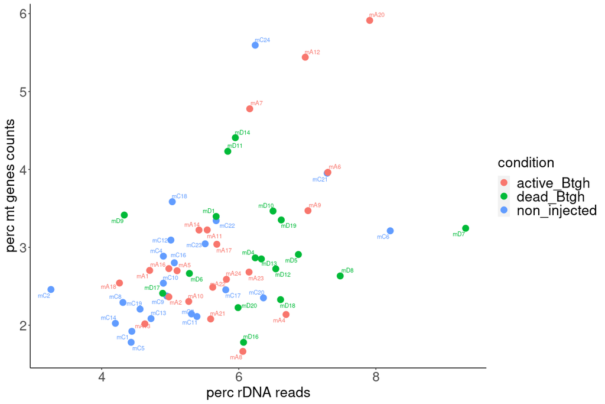

I do not exclude any embryos based on above plot.

# 3 Counts of Btgh RNA molecules

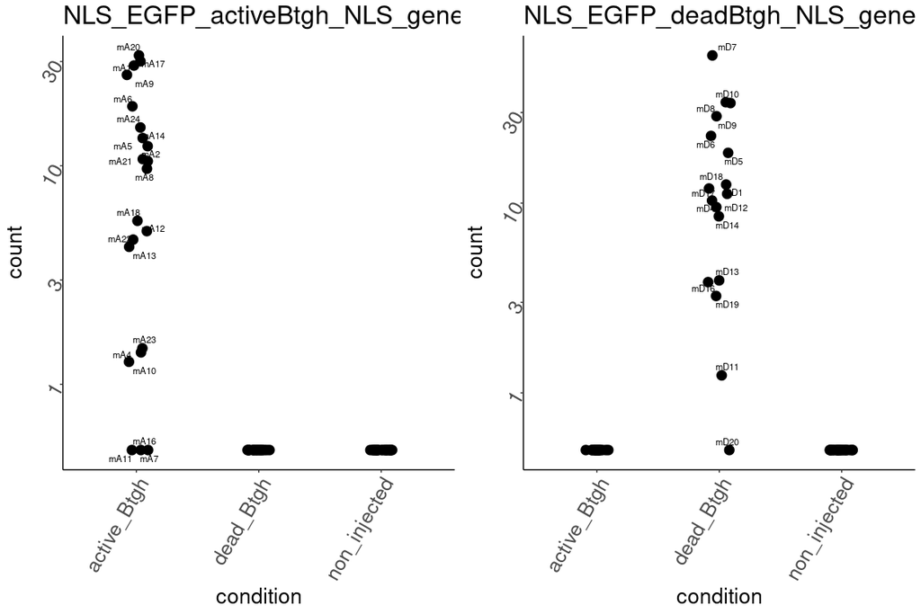

Based on the plots above, I exclude samples mA11, mA16, mA7, mD20 because no read mapping to Btgh mRNA is found. From now on, I also remove Btgh from the counts table.

# 4 Establishing sex of embryos

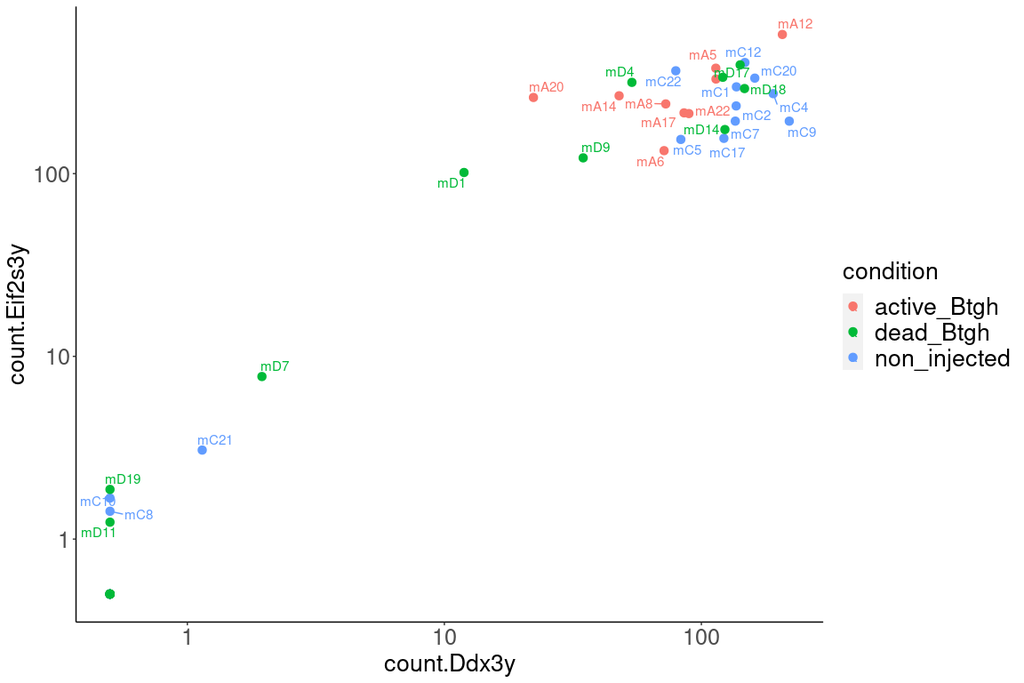

# 5 Sample clustering

## 5.1 Heatmap for quality assessment

After applying the log2(n + 1) transformation, I plot heatmaps of normalized counts for top highly expressed genes to check for eventual big sample heterogeneity present in the dataset.

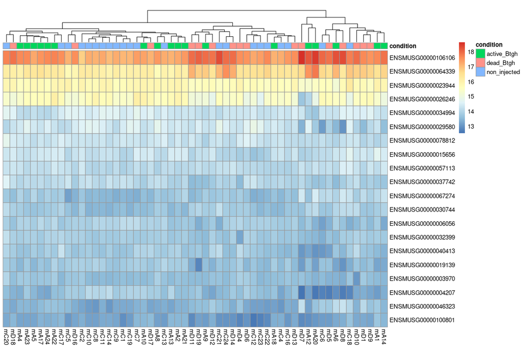

Highly abundant mitochondrial rRNA genes (such as the ones at the top of the heatmap) show quite some variation among samples. This could drive clustering in future PCAs which is not due to biological differences. However, I remove all rRNA genes from the counts table before proceeding with PCA and the PCA does not change (not shown), therefore I decide to proceed without removing them.